# Network Analysis in Python

## Laila A. Wahedi, PhD

### Massive Data Institute Postdoctoral Fellow McCourt School of Public Policy

### Follow along:

- Slides: http://Wahedi.us, Tutorial
- Interactive Notebook: https://notebooks.azure.com/Laila/projects/mdi-network-analysis-workshop

# Follow Along

1. Go to https://notebooks.azure.com/Laila/libraries/MDI-workshopFA18
2. Clone the directory

[figure not shown]

# Follow Along

1. Sign in with any Microsoft Account (Hotmail, Outlook, Azure, etc.)
   - Create a folder to put it in, mark as private or public

[figure not shown]

# Follow Along

1. Open a notebook
   - Open *this* notebook to have the code to play with
   - Open a blank notebook to follow along and try on your own.

[figure not shown]

# Do you get this error?

### HTTP Error 400. The size of the request headers is too long

# Clear your cookies then refresh the browser.

# Your Environment

- Jupyter Notebook Hosted in Azure
- Want to install it at home?
  - Install the Anaconda distribution of Python https://www.anaconda.com/download/
  - Install Jupyter Notebooks http://jupyter.org/install

# Your Environment

- ctrl/apple+ enter runs a cell

[figure not shown]

# Your Environment

- Persistent memory
  - If you run a cell, results remain as long as the kernel

### ORDER MATTERS!

[figure not shown]

```python
foo = 'some variable content'
```

```python
print(foo)
```

```
some variable content
```

# Your Environment: Saving

- If your kernel dies, data are gone.
- Not R or Stata, you can't save your whole environment
- Data in memory more than spreadsheets
- Think carefully about what you want to save and how.

# Easy Saving: Pickle

- dump to save the data to hard drive (out of memory)
- Contents of the command:
  - variable to save,
  - File to dump the variable into:
    - open(  
      "name of file in quotes",  
      "wb") "Write Binary"
- Note: double and single quotes both work

```python
mydata = [1,2,3,4,5,6,7,8,9,10]
pickle.dump(mydata, open('mydata.p','wb'))
mydata = pickle.load(open("mydata.p","rb"))
```

# Get your environment ready

- We'll cover the basics later, for now start installing and loading packages by running the following code:

```python
import networkx as nx
import pandas as pd
import numpy as np
import pickle
import matplotlib.pyplot as plt
%matplotlib inline
```

# What is a network?

- Nodes/ Vertices
- Links/ edges/ ties/ arcs
- Weights
- Also called a graph

# Any Relationship or Interaction

## Examples

- People linked by friendship
- People linked by acquaintance
- People who shop at the same store
- Stores in the same zip code
- Stores with the same distributor
- Movies with the same actors
- Words in the same sentence

# Bipartite: Networks with two types of node

- People and the stores they shop in
- Movies and actors
- Words and authors
- What are some other examples?

# Weighted: Networks with ties of different strength

- Twitter users linked by *number* of retweets
- People linked by distance between homes
- Cities linked by dollars of trade
- Cities linked by number of travelers

# Directed Networks:

### Edges are not always symmetrical

- Twitter user @Ahmad may retweet @Bethany more often than @Bethany retweets Ahmad
- Mexico buys from the US more than the US buys from Mexico
- User mentions on Twitter
- Outgoing phone calls between people
- Friendship rankings: Bobathy may list Amira as a friend on a survey without Amira listing Bobathy

#### Weighted and directed networks are related. Which are weighted and which are unweighted?

#### When are weighted networks not directed?

# Representing a Network: Edge List

- Dyads
- Each row contains a pair of nodes indicating a tie
- A Third Column Cindicates weight
- Order may indicate direction of edge

```python
edges = [('Fred', 'Maria'),
         ('Fred', 'Samir'),
         ('Fred', 'Jose',),
         ('Maria', 'Sonya',),
         ('Samir','Jose'),
         ('Samir','Sonya'),]
```

# Make this a weighted, undirected network

```python
edges_weighted = [('Fred', 'Maria', 3),
                 ('Fred', 'Samir', 6),
                 ('Fred', 'Jose', 2),
                 ('Maria', 'Sonya', 1),
                 ('Samir','Jose',3),
                 ('Samir','Sonya',5)]
```

# What would you need to do to make this directed?

```python
edges_directed = [('Fred', 'Maria', 3),
                 ('Fred', 'Samir', 6),
                 ('Fred', 'Jose', 2),
                 ('Maria', 'Sonya', 1),
                 ('Samir','Jose',3),
                 ('Samir','Sonya',5),
                ('Maria', 'Fred', 2),
                 ('Samir', 'Fred', 4),
                 ('Jose', 'Fred', 6),
                 ('Sonya', 'Maria', 3),
                 ('Jose','Samir',3),]
```

# Representing a network: Adjacency Matrix

- nxn matrix of nodes, where position i,j indicates relationship between node i and node j
  - Index position corresponds with nodes. Keep the order straight
- Can be symmetrical or directed, use weights or indicators with 1
- Less space efficient for sparse networks, but convenient for linear algebra operations
- Use Numpy package, imported as np to make matrices
  - Index as (row, column)
- Why: Do matrix operations on whole network

# Representing a network: Adjacency Matrix

```python
adj = np.zeros((5,5))
edge_index = [(0,1),(0,2),(0,3),
     (1,0),(1,4),
     (2,0),(2,3),(2,4),
     (3,0),(3,2),
     (4,1),(4,2)]
for p in edge_index:
    adj[p] = 1
adj
```

```
array([[ 0.,  1.,  1.,  1.,  0.],
       [ 1.,  0.,  0.,  0.,  1.],
       [ 1.,  0.,  0.,  1.,  1.],
       [ 1.,  0.,  1.,  0.,  0.],
       [ 0.,  1.,  1.,  0.,  0.]])
```

# Representing a network: Adjacency Matrix

- To keep your labels, use the Pandas package, imported as pd

```python
nodes = ['Fred','Maria','Samir','Jose','Sonya','Freya','Hasan']
adj_labeled = pd.DataFrame(adj,columns=nodes,index=nodes)
adj_labeled
```

[output not shown]

# What research are you interested in?

# How might we construct a network from it?

# Representing A network in Python: Networkx Object

- Using the networkx package, imported as nx
- Package designed to hold network data, visualize it, and to perform basic exploratory analysis

# Instantiating Our Network

- Declare a graph object
- Graph is another term for network
- Add your nodes or vertices
- Add your edges from an edgelist

```python
G = nx.Graph()
G.add_nodes_from(nodes)
G.add_edges_from(edges)
G
```

```
<networkx.classes.graph.Graph at 0x7f6a14a1f978>
```

# View Your Data:

### Who is in your network?

### Who is friends with who?

```python
print(G.nodes)
```

[output not shown]

```python
G.edges()
```

```
EdgeView([('Fred', 'Maria'), ('Fred', 'Samir'), ('Fred', 'Jose'), ('Maria', 'Sonya'), ('Samir', 'Jose'), ('Samir', 'Sonya')])
```

# View Your Data:

### Who is Fred friends with?

```python
print(G['Fred'])
```

```
{'Maria': {}, 'Samir': {}, 'Jose': {}}
```

# Add Some Friends

```python
G.add_nodes_from(['Freya','Hasan'])
G.add_edges_from([('Sonya','Freya'),('Sonya','Hasan')])
```

# View Your Data:

### Draw a quick picture

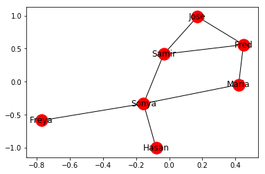

```python
nx.draw_networkx(G, with_labels = True)
```

# Make a Weighted Network:

- Add weighted edges instead of unweighted edges
- Stores weight attribute in the edges
- Can also store node attributes

```python
G_weighted = nx.Graph()
G_weighted.add_nodes_from(nodes)
G_weighted.add_weighted_edges_from(edges_weighted)
nx.set_node_attributes(G_weighted,
                       {'Fred':16,
                       'Maria:':15,
                       'Samir':15,
                       'Jose':15,
                       'Sonya':14},
                      'age')
```

# Make a Directed Network:

- Use a DiGraph object
- Can also use weighted edges
- Stores weight attribute in the edges

```python
G_dir = nx.DiGraph()
G_dir.add_nodes_from(nodes)
G_dir.add_weighted_edges_from(edges_directed)
nx.set_node_attributes(G_dir,
                       {'Fred':16, 'Maria:':15,
                       'Samir':15,'Jose':15,
                       'Sonya':14}, 'age')
```

# View Your Data:

- Friends are no longer symmetrical

```python
print(G_dir['Samir'])
print(G_dir['Jose'])
```

```
{'Jose': {'weight': 3}, 'Sonya': {'weight': 5}, 'Fred': {'weight': 4}}
{'Fred': {'weight': 6}, 'Samir': {'weight': 3}}
```

# View Your Data:

- View node attributes
- View weights

```python
G_dir.nodes['Samir']['age']
```

```
15
```

```python
G_dir['Samir']['Fred']['weight']
```

```
4
```

# Make a Bipartite Network:

- **Two node sets**
- Edges between node sets
- No edges within node sets

```python
G_bi = nx.Graph()
G_bi.add_nodes_from(['Georgetown',
                     'George Mason',
                     'George Washington'],
                   bipartite = 0)
G_bi.add_nodes_from(['Fred','Jose',
                    'Ayesha','Sara',
                    'Bethany','Bobathy'],
                    bipartite = 1
                   )
```

# Make a Bipartite Network:

- Two node sets
- **Edges between node sets**
- **No edges within node sets**

```python
G_bi.add_edges_from([('Georgetown','Fred'),
                    ('Georgetown','Jose'),
                     ('Georgetown','Ayesha'),
                     ('George Washington','Fred'),
                    ('George Washington','Jose'),
                    ('George Washington','Sara'),
                     ('George Mason','Bethany'),
                     ('George Mason','Bobathy')
                    ])
```

# Project to unipartite

- Ties between universities that admitted the same students
- Bipartite set treated as attribute label

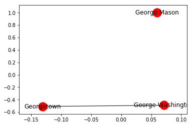

```python
schools = []
for node, data in G_bi.nodes(data=True):
    if data['bipartite']==0:
        schools.append(node)
G_schools = nx.bipartite.projected_graph(G_bi, schools)
nx.draw_networkx(G_schools, with_labels=True)
```

# Make G_bi a weighted graph

```python
G_bi.add_weighted_edges_from([('Georgetown','Fred',10000),
                        ('Georgetown','Jose',0),
                         ('Georgetown','Ayesha',20000),
                         ('George Washington','Fred',7000),
                        ('George Washington','Jose',10000),
                        ('George Washington','Sara',0),
                         ('George Mason','Bethany',30000),
                         ('George Mason','Bobathy',0)
                        ])
```

# Back to the Friendship Network

- Who is most popular?
- Who is most powerful?
- Why?

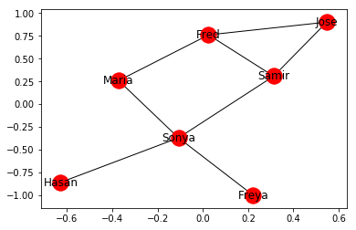

```python
nx.draw_networkx(G)
```

# Centrality

- Way to measure the nature of the connectedness of a group
- Many centrality measures
- Use theory to pick one.

#### Some common measures:

# Degree Centrality

- Number of ties, or normalized number of ties
- Sum of rows
- In-degree: number of edges to a node
- Out-degree: number of edges from a node
- When?

```python
deg = nx.degree_centrality(G)
print(deg)
```

```
{'Fred': 0.5, 'Maria': 0.3333333333333333, 'Samir': 0.5, 'Jose': 0.3333333333333333, 'Sonya': 0.6666666666666666, 'Freya': 0.16666666666666666, 'Hasan': 0.16666666666666666}
```

# Eigenvector Centrality

- Connectedness to other well-connected nodes
- Theoretical Implication: A lot of work to maintain ties to everyone, sometimes just as good to know someone who knows everyone.
  - Finding a job
  - Rumors
  - Supply
- Requires connected network
- Cannot compare across networks

### When might eigenvector centrality be less useful?

# Calculating Eigenvector Centrality

- Take eigenvector for maximum eigenvalue
- nx.eigenvector_centrality uses a different method that usually converges to the same result, but sometimes errors.

```python
eig_c = nx.eigenvector_centrality_numpy(G)
toy_adj = nx.adjacency_matrix(G)
print(eig_c)
val,vec = np.linalg.eig(toy_adj.toarray())
print(val)
vec[:,0]
```

```
{'Fred': 0.46672895953759114, 'Maria': 0.35495662631912422, 'Samir': 0.49598948281898347, 'Jose': 0.36847650119192471, 'Sonya': 0.4606661098595255, 'Freya': 0.17631804784296684, 'Hasan': 0.17631804784296681}
[ 2.6126997   1.34352222 -2.29002215  0.28331905 -1.24305532 -0.70646349
  0.        ]
```

```
array([-0.46672896, -0.35495663, -0.49598948, -0.3684765 , -0.46066611,
       -0.17631805, -0.17631805])
```

# Betweenness Centrality

- Proportional to the number of shortest paths that pass through a given node
- How important is that node in connecting other nodes

```python
betw = nx.betweenness_centrality(G)
print(betw)
```

```
{'Fred': 0.1, 'Maria': 0.1, 'Samir': 0.3, 'Jose': 0.0, 'Sonya': 0.6333333333333333, 'Freya': 0.0, 'Hasan': 0.0}
```

# Centrality Measures Are Different

- Select based on theory you want to capture
- Correlation between measures differs across networks
- Take a minute to play around with the network and see how the relationships change

```python
cent_scores = pd.DataFrame({'deg':deg,'eig_c':eig_c,'betw':betw})
print(cent_scores.corr())
cent_scores
```

```
            deg     eig_c      betw
deg    1.000000  0.914429  0.860781
eig_c  0.914429  1.000000  0.628927
betw   0.860781  0.628927  1.000000
```

|  | deg | eig_c | betw |
| --- | --- | --- | --- |
| Fred | 0.500000 | 0.466729 | 0.100000 |
| Freya | 0.166667 | 0.176318 | 0.000000 |
| Hasan | 0.166667 | 0.176318 | 0.000000 |
| Jose | 0.333333 | 0.368477 | 0.000000 |
| Maria | 0.333333 | 0.354957 | 0.100000 |
| Samir | 0.500000 | 0.495989 | 0.300000 |
| Sonya | 0.666667 | 0.460666 | 0.633333 |

# Difference in Measures

- Sonya has the most friends
- Sonya's friends are not as well connected, lowering her eigenvector centrality
- Fred and Samir have better connected friends
- Hasan and Freya have no connection to the others except through Sonya, giving her high betweenness

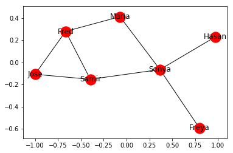

```python
nx.draw_networkx(G)
```

# Florentine Marriage Networks

- Families in this graph are connected when there are marriage ties between them
- Calculate the centrality scores
- Who is the most powerful?

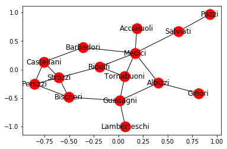

```python
florentine = nx.generators.social.florentine_families_graph()
nx.draw_networkx(florentine)
```

# Florentine Centrality

```python
deg = nx.degree_centrality(florentine)
betw = nx.betweenness_centrality(florentine)
eigc = nx.eigenvector_centrality(florentine)
cent_scores = pd.DataFrame({'deg':deg,'eig_c':eigc,'betw':betw})
cent_scores.sort_values(['deg','eig_c','betw'])
```

|  | deg | eig_c | betw |
| --- | --- | --- | --- |
| Pazzi | 0.071429 | 0.044815 | 0.000000 |
| Ginori | 0.071429 | 0.074925 | 0.000000 |
| Lamberteschi | 0.071429 | 0.088793 | 0.000000 |
| Acciaiuoli | 0.071429 | 0.132157 | 0.000000 |
| Salviati | 0.142857 | 0.145921 | 0.142857 |
| Barbadori | 0.142857 | 0.211706 | 0.093407 |
| Albizzi | 0.214286 | 0.243961 | 0.212454 |
| Castellani | 0.214286 | 0.259020 | 0.054945 |
| Peruzzi | 0.214286 | 0.275722 | 0.021978 |
| Bischeri | 0.214286 | 0.282794 | 0.104396 |
| Tornabuoni | 0.214286 | 0.325847 | 0.091575 |
| Ridolfi | 0.214286 | 0.341554 | 0.113553 |
| Guadagni | 0.285714 | 0.289117 | 0.254579 |
| Strozzi | 0.285714 | 0.355973 | 0.102564 |
| Medici | 0.428571 | 0.430315 | 0.521978 |

# Florentine Centrality

- Which measure best captures Medici power? Why?
- What's up with Guadagni's betweenness vs Stozzi?
- Why does Strozzi have high eigenvector centrality?

# Karate Club Graph

- Compare 0 and 32/33
  - Shared influence
- Compare 5/6 with 27/28
  - Neighborhood density
- Why is eigenvector better correlated with degree here than in our friend graph?
  - Triangles!

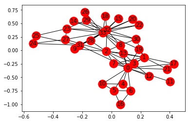

```python
karate = nx.generators.social.karate_club_graph()
nx.draw_networkx(karate)
```

# Karate Club Graph

- Compare 0 and 32/33
  - Shared influence
- Compare 5/6 with 27/28
  - Neighborhood density
- Why is eigenvector better correlated with degree here than in our friend graph?
  - Triangles!

```python
deg = nx.degree_centrality(karate)
betw = nx.betweenness_centrality(karate)
eigc = nx.eigenvector_centrality(karate)
cent_scores = pd.DataFrame({'deg':deg,'eig_c':eigc,'betw':betw})
cent_scores.sort_values(['deg','eig_c','betw'])
```

|  | deg | eig_c | betw |
| --- | --- | --- | --- |
| 11 | 0.030303 | 0.052854 | 0.000000 |
| 16 | 0.060606 | 0.023635 | 0.000000 |
| 26 | 0.060606 | 0.075582 | 0.000000 |
| 12 | 0.060606 | 0.084252 | 0.000000 |
| 17 | 0.060606 | 0.092397 | 0.000000 |
| 21 | 0.060606 | 0.092397 | 0.000000 |
| 14 | 0.060606 | 0.101406 | 0.000000 |
| 15 | 0.060606 | 0.101406 | 0.000000 |
| 18 | 0.060606 | 0.101406 | 0.000000 |
| 20 | 0.060606 | 0.101406 | 0.000000 |
| 22 | 0.060606 | 0.101406 | 0.000000 |
| 9 | 0.060606 | 0.102675 | 0.000848 |
| 24 | 0.090909 | 0.057054 | 0.002210 |
| 25 | 0.090909 | 0.059208 | 0.003840 |
| 10 | 0.090909 | 0.075966 | 0.000631 |
| 4 | 0.090909 | 0.075966 | 0.000631 |
| 28 | 0.090909 | 0.131079 | 0.001795 |
| 19 | 0.090909 | 0.147911 | 0.032475 |
| 6 | 0.121212 | 0.079481 | 0.029987 |
| 5 | 0.121212 | 0.079481 | 0.029987 |
| 27 | 0.121212 | 0.133479 | 0.022333 |
| 29 | 0.121212 | 0.134965 | 0.002922 |
| 7 | 0.121212 | 0.170955 | 0.000000 |
| 30 | 0.121212 | 0.174760 | 0.014412 |
| 23 | 0.151515 | 0.150123 | 0.017614 |
| 13 | 0.151515 | 0.226470 | 0.045863 |
| 8 | 0.151515 | 0.227405 | 0.055927 |
| 31 | 0.181818 | 0.191036 | 0.138276 |
| 3 | 0.181818 | 0.211174 | 0.011909 |
| 1 | 0.272727 | 0.265954 | 0.053937 |
| 2 | 0.303030 | 0.317189 | 0.143657 |
| 32 | 0.363636 | 0.308651 | 0.145247 |
| 0 | 0.484848 | 0.355483 | 0.437635 |
| 33 | 0.515152 | 0.373371 | 0.304075 |

# Speaking of triangles: Transitivity

- Extent to which friends have friends in common
- Probability two nodes are tied given that they have a partner in common
- Make a more transitive network:

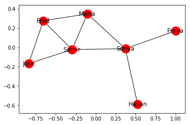

```python
G_trans = G.copy()
G_trans.add_edges_from([('Samir','Maria')])
nx.draw_networkx(G_trans)
```

# Transitivity

- Extent to which friends have friends in common
- Probability two nodes are tied given that they have a partner in common ### Look at transitivity and triangles in the two networks

```python
print("Transitivity:")
print(nx.transitivity(G))
print(nx.transitivity(G_trans))
print("Triangles:")
print(nx.triangles(G))
print(nx.triangles(G_trans))
```

[output not shown]

# Clustering Coefficient

- Individual Nodes:
  - Proportion of possible triangles through a given node
- Whole Network
  - Average clustering across whole network

```python
print("Clustering coefficient")
print(nx.clustering(G))
print(nx.clustering(G_trans))
print("Average Clustering")
print(nx.average_clustering(G))
print(nx.average_clustering(G_trans))
```

[output not shown]

# Which is more clustered? Florentine or Karate?

[figure not shown]

# Florentine has few triangles

```
0.16
```

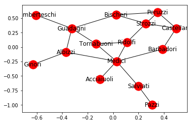

```python
nx.draw_networkx(florentine)
nx.average_clustering(florentine)
```

# Karate Club has a lot of triangles

- Why might they be different?

```
0.5706384782076823
```

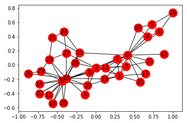

```python
nx.draw_networkx(karate)
nx.average_clustering(karate)
```

# Different Structures Are Produced by and Produce Different Behaviors

- Triadic closure -> transitivity on friendship network
- Less redundancy in strategic Medicci marriage contracts. Triangles inefficient
- Clustering captures tendency toward closure globally. What might it miss?

# What might we miss?

```
0.0
```

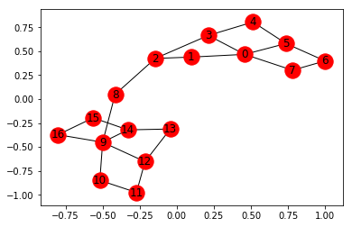

```python
squares = nx.Graph()
se = [(0,1),(1,2),(2,3),(3,0),(0,5),(4,5),(3,4),
    (5,6),(6,7),(7,0),(2,8),(8,9)]
se2 = [(i[0]+9,i[1]+9) for i in se[:-2]]
se.extend(se2)
squares.add_nodes_from(range(17))
squares.add_edges_from(se)
nx.draw_networkx(squares)
nx.average_clustering(squares)
```

# What Can We Do?

- Count n-cycles.
  - Count all cycles, keep those below threshold

```python
nx.cycle_basis(squares)
```

```
[[5, 6, 7, 0],
 [3, 4, 5, 0],
 [1, 2, 3, 0],
 [14, 15, 16, 9],
 [12, 13, 14, 9],
 [10, 11, 12, 9]]
```

# What Can We Do?

- Square clustering ### Intuitive names like clustering are nice, but always know what you're measuring and check if it's appropriate for your network

```python
clustering_coefs = nx.square_clustering(squares).values()
np.mean(list(clustering_coefs))
```

```
0.6147058823529411
```

# Community Detection

- Divide the network into subgroups using different algorithms
- Examples
  - Percolation: find communities with fully connected cores
  - Minimum cuts (nodes): Find the minimum number of nodes that, if removed, break the network into multiple components. Progressively remove them.
  - **Girvan Newman Algorithm:** Remove ties with highest betweenness, continue until network broken into desired number of communities

```python
coms = nx.algorithms.community.centrality.girvan_newman(G)
i = 2
for com in itertools.islice(coms,4):
    print(i, ' communities')
    i+=1
    print(tuple(c for c in com))
```

```
2  communities
({'Jose', 'Maria', 'Samir', 'Fred'}, {'Freya', 'Hasan', 'Sonya'})
3  communities
({'Jose', 'Maria', 'Samir', 'Fred'}, {'Hasan', 'Sonya'}, {'Freya'})
4  communities
({'Jose', 'Samir', 'Fred'}, {'Maria'}, {'Hasan', 'Sonya'}, {'Freya'})
5  communities
({'Fred'}, {'Maria'}, {'Samir', 'Jose'}, {'Hasan', 'Sonya'}, {'Freya'})
```

# Why Detect Communities

- Learn something about how an unknown network is organized
- Generate hypotheses.
  - Why did these communities emerge?
  - How do these communities affect the behavior of members?
  - How do they relate to attributes of the members?
  - How do they evolve over time, how do different networks compare?

#### What are some examples?

# Assessing Community Detection:

- Density: Number of ties / maximum number
- Maximum number of ties: Every node in network has a tie
- Modularity: Fraction of edges within a group / expected edges in random graph
  - Is the density within each community greater than a random network generated with the same density of the overall network

```python
nx.density(G)
```

[output not shown]

# Preview: Random Graphs

- Different methods to capture different properties
- Compare random graph with desired properties to real graph
- Today: Erdos-Renyi Graph
  - Takes all possible edges
  - Each edge has a probability p of being realized
  - Produces graph with desired average density
  - Does not capture other properties common in real world graphs #### More next week!

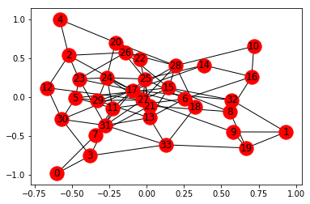

```python
G_rand = nx.gnp_random_graph(len(karate.nodes),
                             nx.density(karate))
nx.draw_networkx(G_rand)
```

# Modularity and Random Graphs

- Compare number of ties within community to expected number if the graph were an Erdos Renyi Graph

```python
nx.average_clustering(karate)
```

```
0.5706384782076823
```

```python
nx.average_clustering(G_rand)
```

```
0.1254435107376284
```

# Compare the clustering visually:

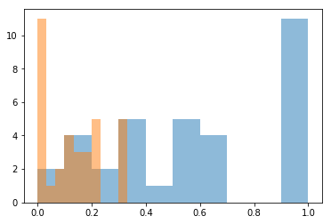

```python
#View clusters
plt.hist(nx.clustering(karate).values(), alpha = .5)
plt.hist(nx.clustering(G_rand).values(), alpha = .5)
```

# Compare the clustering in florentine to a random network

- How do they differ?

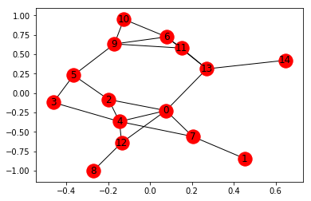

```python
G_rand_f = nx.gnp_random_graph(len(florentine.nodes),
                             nx.density(florentine))
nx.draw_networkx(G_rand_f)
```

# Compare the clustering in florentine to a random network

- How do they differ?

[output not shown]

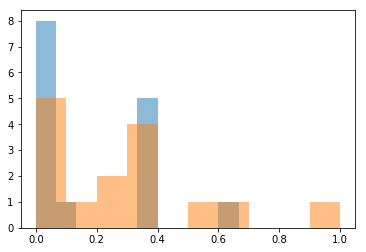

```python
print('Florentine: ',nx.average_clustering(florentine))
print('Random: ', nx.average_clustering(G_rand_f))
plt.hist(nx.clustering(florentine).values(),alpha=.5)
plt.hist(nx.clustering(G_rand_f).values(), alpha = .5)
```

# Modularity Based Performance Measurement

- Modularity: Fraction of edges within group - expected number of edges
- Networkx performance metric:
  - (Number of edges within groups - Number of edges between groups)/(Total Edges)

```python
coms = nx.algorithms.community.centrality.girvan_newman(squares)
for com in itertools.islice(coms,1):
    partition = tuple(list(c) for c in com)
nx.algorithms.community.quality.performance(squares,partition)
```

```
0.6764705882352942
```

# Compare the insularity of the communities in the florentine and karate networks

- Why is it that so?

```python
coms = nx.algorithms.community.centrality.girvan_newman(karate)
for com in itertools.islice(coms,1):
    k_partition = tuple(list(c) for c in com)
nx.algorithms.community.quality.performance(karate,k_partition)
```

```
0.6114081996434938
```

```python
coms = nx.algorithms.community.centrality.girvan_newman(florentine)
for com in itertools.islice(coms,1):
    fl_partition = tuple(list(c) for c in com)
nx.algorithms.community.quality.performance(florentine,fl_partition)
```

```
0.41904761904761906
```

# Visualizing the networks

- Matplotlib package, imported as plt
  - %matplotlib inline magic to make it plot in the notebook

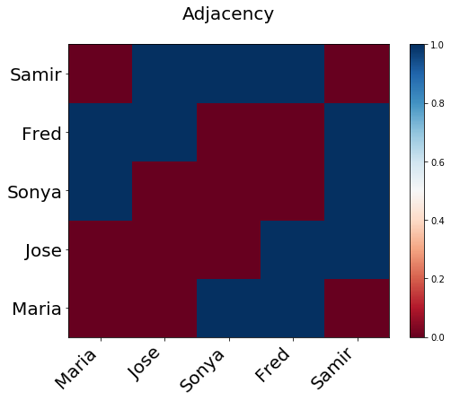

```python
order = adj_labeled.sum().sort_values().index
adj_labeled = adj_labeled.loc[order,order]
plt.figure(figsize = (8,6))
plt.pcolor(adj_labeled,cmap=plt.cm.RdBu)
plt.yticks(np.arange(0.5, 5, 1), adj_labeled.index, fontsize = 20)
plt.xticks(np.arange(0.5, 5, 1), adj_labeled.columns, rotation =45, ha='right', fontsize=20 )
plt.title('Adjacency\n',fontsize=20)
cbar =plt.colorbar()
```

# Graph Plotting Algorithms

- Can learn something by placing the nodes in an intelligent way
- Force Algorithm: Put nodes that are connected closer together

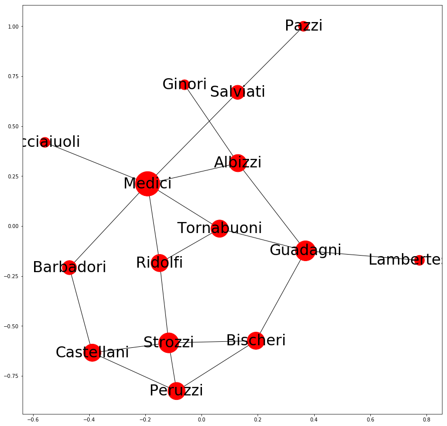

```python
plt.figure(figsize=(15,15))
pos = nx.spring_layout(florentine)
deg = nx.degree(florentine)
deg = [deg[k]*400 for k in florentine.nodes]
nx.draw_networkx(florentine,pos=pos, with_labels=True,
                node_size=deg,font_size=30)
```

# Add Color

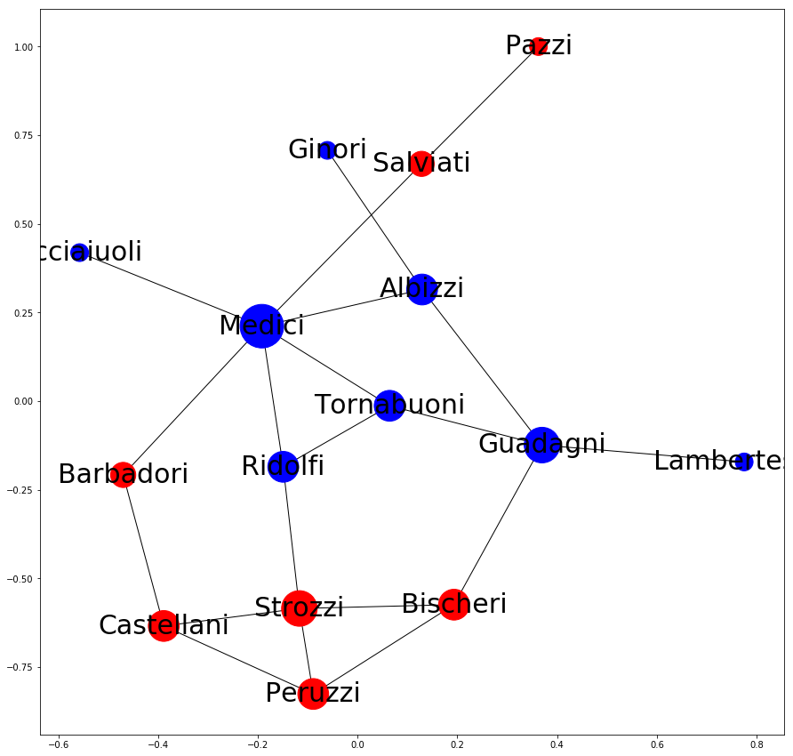

```python
plt.figure(figsize=(15,15))
colors = []
for n in florentine.nodes:
    if n in fl_partition[0]:
        colors.append('blue')
    else:
        colors.append('red')
nx.draw_networkx(florentine,pos=pos, with_labels=True,
                node_size=deg,font_size=30, node_color = colors)
```

# Draw the Florentine Network with Three Partitions

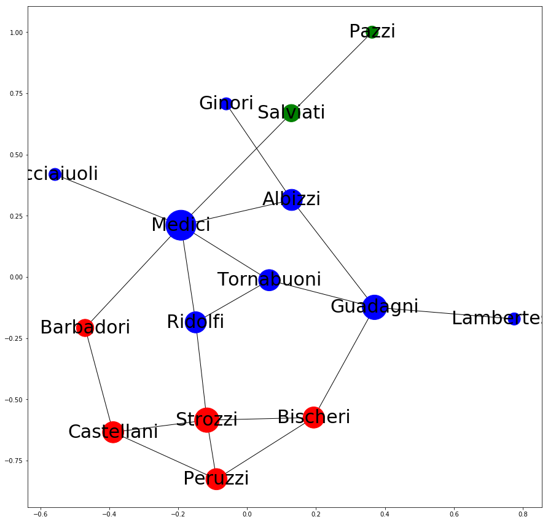

```python
coms = nx.algorithms.community.centrality.girvan_newman(florentine)
for com in itertools.islice(coms,2):
    fl_partition = tuple(list(c) for c in com)
nx.algorithms.community.quality.performance(florentine,fl_partition)
colors = []
for n in florentine.nodes:
    if n in fl_partition[0]:
        colors.append('blue')
    elif n in fl_partition[1]:
        colors.append('red')
    else:
        colors.append('green')
plt.figure(figsize=(15,15))
nx.draw_networkx(florentine,pos=pos, with_labels=True,
                node_size=deg,font_size=30, node_color = colors)
```

# Next Time: Making Inferences

- Network Questions
- Network Properties
  - Degree distributions
  - Centralization
- Random Networks
- Regressions with Network Variables